# Macrofauna Production

Chih-Lin Wei

2023-03-03

```r
library(bbbs)
#library(devtools)
#install_github("HenrikeAndresen/BenthicPro")
library(BenthicPro)
library(ggplot2)
library(plyr)
library(doBy)
library(readxl)
library(knitr)
library(nlme)

large <- theme(legend.title = element_text(size=20),
        legend.text = element_text(size=20),
        axis.title = element_text(size=20),
        axis.text = element_text(size=20))
rotate <- theme(axis.text.x = element_text(size=20, angle=60, hjust=0.5))

# dark theme for ggplot
dark <- theme(plot.background = element_rect(colour = 'NA', fill = 'gray10'),
        panel.background = element_rect(colour = 'NA', fill = 'transparent'),
        legend.background = element_rect(colour = 'NA', fill = 'transparent'),
        legend.title = element_text(colour = 'white', size=20),
        legend.text = element_text(colour = 'white', size=20),
        axis.title = element_text(colour = 'white', size=20),
        axis.text = element_text(colour = 'white', size=20),
        axis.ticks = element_line(colour = 'white'),
        panel.border = element_rect(fill = 'NA', colour = 'white'),
        panel.grid.major = element_line(colour = 'gray30'),
        panel.grid.minor = element_line(colour = 'gray20'))
```

# 1 Data preparation

We coverted the macrofauna individual body mass (in mg weight weight) into energy content [J] using [conversion factors](http://www.thomas-brey.de/science/DBconversion/datafiles/Conversion04.zip) from Brey (2010) and then estimated macrofaunal production to biomass ratio (P/B) and annual secondary production (P) from three continuous parameters (temperature, water depth, body mass) and 17 categorical parameters (5 taxa, 7 lifestyle, 4 environment, and and state of exploitation) using the Artificial Neural Network model (ANN) developed by Brey (2012) and available as R package [BenthicPro](https://rdrr.io/github/HenrikeAndresen/BenthicPro/man/BenthicPB.html). The large nematode production to biomass ratio was estimated using the following equation developed by Schwinghamer et al. (1986): $P/B = 0.073*M^{-0.337}$, where M is individual body mass [kcal].

```r
dat <- subset(mac, Cruise=="OR1_1096"|Cruise=="OR1_1102"|Cruise=="OR1_1114"|Cruise=="OR1_1126"|Cruise=="OR1_1128"|Cruise=="OR1_1132")
dat.sum <- summaryBy(Wt~Habitat+Cruise+Station+Deployment+Tube+Taxon, data=dat, FUN=c(sum, length))
names(dat.sum)[-1:-6] <- c("Wt", "Count")
dat.sum$Sample.area <- mac$Area[match(with(dat.sum, paste(Cruise, Station)), with(mac, paste(Cruise, Station)))]

# Convert the numbers of polychaete specimen (with head) to abundance
pols <- subset(mac, Taxon=="Polychaeta" & (Condition=="FH" | Condition=="C" | Condition=="FHT"))
pola <- summaryBy(Wt~Habitat+Cruise+Station+Deployment+Tube+Taxon, data=pols, FUN=length, var.names="Count", keep.names = T)
keep <- match(with(pola, paste(Cruise, Station, Deployment, Tube, Taxon)), with(dat.sum, paste(Cruise, Station, Deployment, Tube, Taxon)))
dat.sum$Count[keep] <- pola$Count

# Convert the numbers of complete ophiroid specimens to abundance
ophs <- subset(mac, Taxon=="Ophiuroidea" & Condition=="C")
opha <- summaryBy(Wt~Habitat+Cruise+Station+Deployment+Tube+Taxon, data=ophs, FUN=length, var.names="Count", keep.names = T)
keep <- match(with(opha, paste(Cruise, Station, Deployment, Tube, Taxon)), with(dat.sum, paste(Cruise, Station, Deployment, Tube, Taxon)))
dat.sum$Count[keep] <- opha$Count

# Remove Cyclopoida and Calanoida
dat.sum <- subset(dat.sum, !(Taxon=="Cyclopoida"|Taxon=="Calanoida"))

# Match to marofauna production parameters
dat.sum <- cbind(dat.sum, mpr[match(dat.sum$Taxon, mpr$Taxon), c("ConFac_j2mgwm", "ConFac_j2mgc")])
dat.sum$Bodymass <- with(dat.sum, Wt*ConFac_j2mgwm/Count)

dat.sum <- cbind(dat.sum, env[match(with(dat.sum, paste(Cruise, Station)), with(env, paste(Cruise, Station))), c("Temperature", "Depth")])
dat.sum <- cbind(dat.sum, mpr[match(dat.sum$Taxon, mpr$Taxon), c(-1:-3, -21)])

# Replace with mean temperature by station
temp.mean <- summaryBy(Temperature~Habitat+Station, data=env, FUN=mean, keep.names = TRUE)
dat.sum$Temperature <- temp.mean[match(dat.sum$Station, temp.mean$Station), "Temperature"]


# Calculate P/B ratio
individualPB<-BenthicPB(dat.sum)

# Convert bodymass in J to kcal
# Calculate nematode P/B ratio using Schwinghamer et al. (1986) equation
nemaPB <- 0.073*(dat.sum$Bodymass/4184)^-0.337
individualPB[dat.sum$Taxon == "Nematoda", "annual.PtoB"] <- nemaPB[dat.sum$Taxon == "Nematoda"]

PBresults<-cbind(dat.sum,individualPB)

# annual secondary production in mulligram WM per species and sample per square meter
PBresults$productionW <- with(PBresults, annual.PtoB*Wt/Sample.area)

# annual secondary production in Joule per species and sample per square meter
PBresults$productionJ <- with(PBresults, productionW*ConFac_j2mgwm)

# conversion from Joule to milligram carbon per square meter
PBresults$productionC <- with(PBresults, productionJ/ConFac_j2mgc)

# Average P/B ratio by tube
p2b <- summaryBy(Depth+annual.PtoB+lowerCI+upperCI~Habitat+Cruise+Station+Deployment+Tube, data = PBresults, fun = mean, keep.names = TRUE)

# Summation production by tube
pd <- summaryBy(productionW+productionJ+productionC+Count+Wt~Habitat+Cruise+Station+Deployment+Tube, data = PBresults, fun = sum, keep.names = TRUE)
pd <- cbind(p2b, pd[, -1:-5])

# Remove outlier samples with only 1 individuals
bad <- with(pd, Count <=1 | (Cruise=="OR1_1102" & Station == "GS4") )
dat <- subset(dat, !bad)

se <- function(x) sd(x)/length(x)^0.5
out <- summaryBy(Depth+annual.PtoB+lowerCI+upperCI+productionW+productionJ+productionC~Habitat+Cruise+Station, data = pd, FUN = c(mean, sd, length, se))

out <- out[, c("Habitat", "Cruise", "Station", "Depth.mean", "annual.PtoB.mean", "annual.PtoB.se", "productionW.mean", "productionW.se", "productionJ.mean", "productionJ.se", "productionC.mean", "productionC.se", "Depth.length")]

names(out) <- c("Habitat", "Cruise", "Station", "Depth", "annual.PtoB", "annual.PtoB.se", "productionW", "productionW.se", "productionJ", "productionJ.se", "productionC", "productionC.se", "n")

kable(out)
```

| Habitat | Cruise | Station | Depth | annual.PtoB | annual.PtoB.se | productionW | productionW.se | productionJ | productionJ.se | productionC | productionC.se | n |
| --- | --- | --- | --- | --- | --- | --- | --- | --- | --- | --- | --- | --- |
| Canyon | OR1_1096 | GC1 | 222.000 | 5.278643 | 0.3771859 | 402.47581 | 214.96686 | 2973.3068 | 1965.74280 | 65.784884 | 43.2171119 | 3 |
| Canyon | OR1_1096 | GC2 | 462.000 | 3.989081 | 0.9500532 | 361.57653 | 164.74621 | 1280.6162 | 572.95476 | 27.919791 | 12.6012402 | 3 |
| Canyon | OR1_1096 | GC3 | 655.000 | 3.350710 | 0.1381780 | 351.22308 | 102.48047 | 1237.3593 | 361.03880 | 27.075695 | 7.9001926 | 3 |
| Canyon | OR1_1102 | GC1 | 323.000 | 4.019209 | NA | 242.44233 | NA | 854.1246 | NA | 18.689816 | NA | 1 |
| Canyon | OR1_1102 | GC2 | 482.000 | 4.438166 | 0.5825124 | 47.63195 | 19.48010 | 212.2567 | 47.31942 | 4.891766 | 1.0358558 | 3 |
| Canyon | OR1_1102 | GC3 | 653.000 | 3.256542 | 0.2226629 | 340.80023 | 149.22146 | 1387.4241 | 668.97874 | 31.895430 | 15.2741350 | 3 |
| Canyon | OR1_1102 | GC4 | 1065.200 | 2.686964 | 0.0470145 | 104.98672 | 24.29701 | 775.8172 | 242.63681 | 18.958541 | 6.3157117 | 3 |
| Canyon | OR1_1114 | GC1 | 319.750 | 5.569634 | 0.8581131 | 114.87217 | 34.30319 | 354.7336 | 90.08358 | 7.760774 | 1.9725959 | 5 |
| Canyon | OR1_1114 | GC2 | 478.000 | 4.659603 | 0.4703064 | 187.81788 | 25.30122 | 732.3277 | 106.36418 | 16.295108 | 2.4607174 | 4 |
| Canyon | OR1_1114 | GC3 | 654.750 | 3.408239 | 0.1686700 | 136.28260 | 29.62149 | 937.3109 | 198.56205 | 23.202957 | 4.9997902 | 4 |
| Canyon | OR1_1114 | GC4 | 1051.000 | 2.994079 | 0.2493016 | 595.20617 | 502.95971 | 2230.1525 | 1805.28239 | 49.516082 | 39.6962480 | 6 |
| Canyon | OR1_1126 | GC1 | 318.000 | 4.656435 | 0.3706951 | 67.31823 | 15.05118 | 219.7695 | 41.01509 | 4.808961 | 0.8974855 | 5 |
| Canyon | OR1_1126 | GC3 | 655.000 | 3.182555 | 0.2518926 | 449.44707 | 404.19967 | 1728.1788 | 1359.07532 | 38.682653 | 29.4040139 | 2 |
| Canyon | OR1_1126 | GC4 | 1067.667 | 2.931274 | 0.2095233 | 77.61625 | 19.47869 | 478.4718 | 77.31177 | 11.697942 | 1.8739579 | 4 |
| Slope | OR1_1096 | GS1 | 270.000 | 5.353129 | 0.7716365 | 461.88857 | 206.36933 | 2206.7337 | 1163.67103 | 46.943173 | 25.4294552 | 3 |
| Slope | OR1_1096 | GS2 | 465.000 | 4.887848 | 0.4756988 | 419.54066 | 117.20807 | 1890.1827 | 646.76924 | 42.072925 | 13.8303638 | 3 |
| Slope | OR1_1096 | GS3 | 692.000 | 3.797907 | 0.3414391 | 386.38083 | 88.65606 | 1770.4804 | 790.89964 | 39.390125 | 17.7793612 | 3 |
| Slope | OR1_1102 | GS1 | 278.670 | 5.938684 | 0.1380241 | 4742.77952 | 2689.30096 | 16794.4456 | 9465.10264 | 368.145739 | 206.9903146 | 3 |
| Slope | OR1_1102 | GS2 | 463.540 | 5.029130 | 0.0760002 | 911.77803 | 664.05801 | 3428.7354 | 2463.19703 | 76.386590 | 54.4727306 | 3 |
| Slope | OR1_1102 | GS3 | 682.000 | 3.642994 | 0.4532144 | 198.38910 | 66.54088 | 811.5149 | 251.23874 | 18.173794 | 5.5370372 | 4 |
| Slope | OR1_1114 | GS1 | 279.000 | 5.765565 | 0.0779148 | 2009.02673 | 1290.28961 | 6920.6787 | 3960.54527 | 155.060163 | 90.0556368 | 4 |
| Slope | OR1_1114 | GS2 | 462.000 | 4.388181 | 0.1199973 | 854.78208 | 455.33578 | 3141.6335 | 1627.43367 | 69.724600 | 35.9688156 | 5 |
| Slope | OR1_1114 | GS3 | 690.000 | 4.149432 | 0.2610571 | 280.97378 | 62.43006 | 1205.6207 | 334.87809 | 26.926602 | 7.3244605 | 4 |
| Slope | OR1_1114 | GS4 | 848.000 | 3.694038 | 0.1445674 | 365.07865 | 63.31522 | 1289.3200 | 212.86763 | 28.850664 | 4.4905461 | 4 |
| Slope | OR1_1126 | GS1 | 277.000 | 5.957473 | 0.1284709 | 711.44521 | 115.98214 | 2880.0027 | 528.04771 | 63.492114 | 11.5382847 | 4 |
| Slope | OR1_1126 | GS2 | 463.000 | 4.832048 | 0.1376811 | 381.41827 | 52.56972 | 1395.1041 | 182.08479 | 31.412370 | 3.9780638 | 4 |
| Slope | OR1_1126 | GS3 | 690.000 | 3.891837 | 0.0828398 | 329.78356 | 44.04039 | 1190.7063 | 181.28383 | 26.423226 | 4.0480844 | 4 |
| Slope | OR1_1126 | GS4 | 848.000 | 3.693298 | 0.1141212 | 245.10826 | 58.77875 | 904.8369 | 204.02957 | 20.334013 | 4.5486883 | 4 |

# 2 Production to biomass ratio

## 2.1 Linear regression with depth

```r
splitBy(~Habitat, out) %>% lapply(FUN=function(x)lm(annual.PtoB~Depth, data=x) %>% summary)
```

```
## $Canyon
##
## Call:
## lm(formula = annual.PtoB ~ Depth, data = x)
##
## Residuals:
##      Min       1Q   Median       3Q      Max
## -0.63144 -0.37222  0.03526  0.34230  0.91005
##
## Coefficients:
##               Estimate Std. Error t value Pr(>|t|)
## (Intercept)  5.5393862  0.3026861  18.301 3.92e-10 ***
## Depth       -0.0027515  0.0004577  -6.012 6.10e-05 ***
## ---
## Signif. codes:  0 '***' 0.001 '**' 0.01 '*' 0.05 '.' 0.1 ' ' 1
##
## Residual standard error: 0.4747 on 12 degrees of freedom
## Multiple R-squared:  0.7507, Adjusted R-squared:   0.73
## F-statistic: 36.14 on 1 and 12 DF,  p-value: 6.104e-05
##
##
## $Slope
##
## Call:
## lm(formula = annual.PtoB ~ Depth, data = x)
##
## Residuals:
##      Min       1Q   Median       3Q      Max
## -0.51789 -0.19046  0.06126  0.25504  0.33058
##
## Coefficients:
##               Estimate Std. Error t value Pr(>|t|)
## (Intercept)  6.7061931  0.2178935   30.78 8.69e-13 ***
## Depth       -0.0038964  0.0003844  -10.14 3.09e-07 ***
## ---
## Signif. codes:  0 '***' 0.001 '**' 0.01 '*' 0.05 '.' 0.1 ' ' 1
##
## Residual standard error: 0.2923 on 12 degrees of freedom
## Multiple R-squared:  0.8954, Adjusted R-squared:  0.8867
## F-statistic: 102.7 on 1 and 12 DF,  p-value: 3.093e-07
```

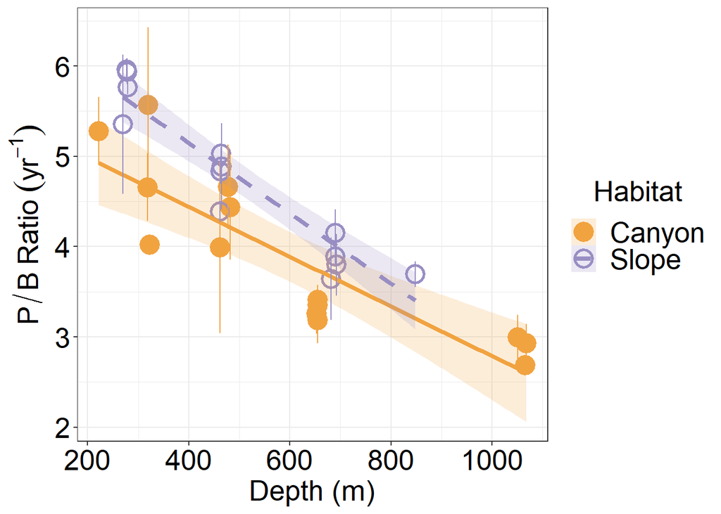

```r
(f4b <- ggplot(data=out,
       aes(x=Depth, y=annual.PtoB,
           ymin=annual.PtoB-annual.PtoB.se, ymax=annual.PtoB+annual.PtoB.se,
           shape=Habitat, colour=Habitat, fill=Habitat, linetype=Habitat))+
  geom_point(size=5, stroke=1.5, position="jitter")+
  stat_smooth(method="lm", formula=y~x, alpha=0.2, size=1.5)+
  geom_errorbar(linetype=1)+
  scale_colour_manual(values=c("#f1a340", "#998ec3"))+
  scale_fill_manual(values=c("#f1a340", "#998ec3"))+
  scale_linetype_manual(values=c(1,2))+
  scale_shape_manual(values=c(19,1))+
  labs(x="Depth (m)", y=expression(P/B~Ratio~(yr^-1)))+
  theme_bw() %+replace% large #%+replace% dark
)
```

```r
#save(f4b, file="../rds/f4b.rds")
```

## 2.2 Generalized Least Squares (GLS) modeling

#### 2.2.0.1 Main test

```r
f <- gls(annual.PtoB ~ Habitat+Depth+Cruise+Habitat:Depth+Habitat:Cruise+Depth:Cruise, data=out, method = "REML")
kable(summary(f)$tTable)
```

|  | Value | Std.Error | t-value | p-value |
| --- | --- | --- | --- | --- |
| (Intercept) | 5.7979036 | 0.5337444 | 10.8626967 | 0.0000000 |
| HabitatSlope | 1.1122834 | 0.4873927 | 2.2821092 | 0.0374974 |
| Depth | -0.0035663 | 0.0010604 | -3.3633073 | 0.0042672 |
| CruiseOR1_1102 | -0.5180542 | 0.7046247 | -0.7352201 | 0.4735450 |
| CruiseOR1_1114 | 0.2097715 | 0.6730084 | 0.3116923 | 0.7595647 |
| CruiseOR1_1126 | -0.5054056 | 0.7081608 | -0.7136877 | 0.4863775 |
| HabitatSlope:Depth | -0.0011230 | 0.0007347 | -1.5286228 | 0.1471692 |
| HabitatSlope:CruiseOR1_1102 | 0.2753596 | 0.4917830 | 0.5599209 | 0.5837991 |
| HabitatSlope:CruiseOR1_1114 | -0.2969002 | 0.4736234 | -0.6268698 | 0.5401691 |
| HabitatSlope:CruiseOR1_1126 | 0.2537512 | 0.4965228 | 0.5110565 | 0.6167508 |
| Depth:CruiseOR1_1102 | 0.0009036 | 0.0012284 | 0.7355685 | 0.4733391 |
| Depth:CruiseOR1_1114 | 0.0006108 | 0.0011740 | 0.5202359 | 0.6104923 |
| Depth:CruiseOR1_1126 | 0.0010636 | 0.0011783 | 0.9026326 | 0.3809874 |

```r
kable(anova(f))
```

|  | numDF | F-value | p-value |
| --- | --- | --- | --- |
| (Intercept) | 1 | 2788.9820994 | 0.0000000 |
| Habitat | 1 | 21.9671379 | 0.0002922 |
| Depth | 1 | 89.9467001 | 0.0000001 |
| Cruise | 3 | 0.7823196 | 0.5220978 |
| Habitat:Depth | 1 | 2.9417545 | 0.1068948 |
| Habitat:Cruise | 3 | 0.6379725 | 0.6021530 |
| Depth:Cruise | 3 | 0.3039474 | 0.8221035 |

Significant habitat and depth effects.

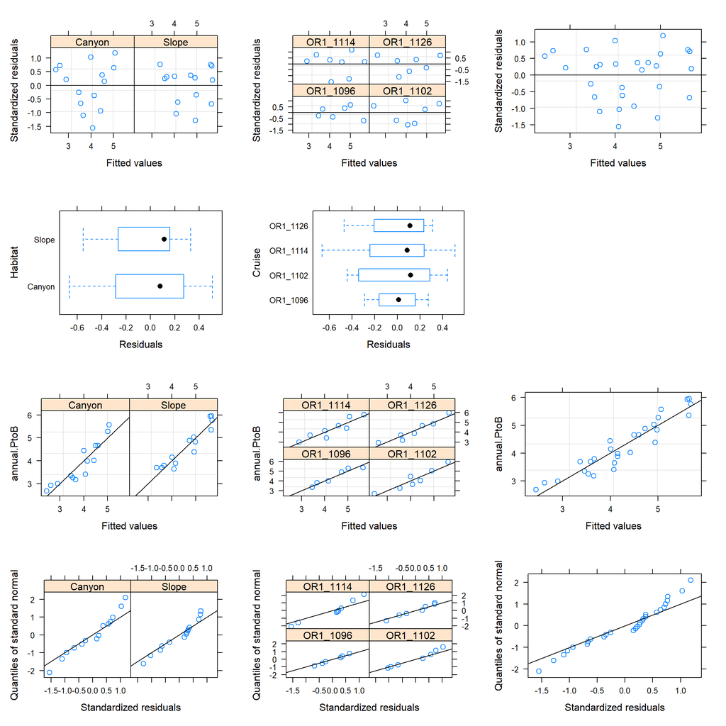

```r
# Function to plot dianotics plot
dianostic_plot <-
  function(f, y){
    # standardized residuals versus fitted values
    a1 <- plot(f, resid(., type = "p") ~ fitted(.) | Habitat, abline = 0)
    a2 <- plot(f, resid(., type = "p") ~ fitted(.) | Cruise, abline = 0)
    a3 <- plot(f, resid(., type = "p") ~ fitted(.), abline = 0)
    # box-plots of residuals
    b1<-plot(f, Habitat ~ resid(.))
    b2 <- plot(f, Cruise ~ resid(.))
    # observed versus fitted values
    c1<-plot(f, paste(paste(y, "fitted(.)", sep="~"), "Habitat", sep="|") %>% formula, abline = c(0,1))
    c2<-plot(f, paste(paste(y, "fitted(.)", sep="~"), "Cruise", sep="|") %>% formula, abline = c(0,1))
    c3<-plot(f, paste(y, "fitted(.)", sep="~") %>% formula, abline = c(0,1))
    # QQ plot
    d1<-qqnorm(f, ~ resid(., type = "p") | Habitat, abline = c(0,1))
    d2<-qqnorm(f, ~ resid(., type = "p") | Cruise, abline = c(0,1))
    d3<-qqnorm(f, ~ resid(., type = "p"), abline = c(0,1))

    print(a1, split=c(1,1,3,4), more=TRUE)
    print(a2, split=c(2,1,3,4), more=TRUE)
    print(a3, split=c(3,1,3,4), more=TRUE)
    print(b1, split=c(1,2,3,4), more=TRUE)
    print(b2, split=c(2,2,3,4), more=TRUE)
    #
    print(c1, split=c(1,3,3,4), more=TRUE)
    print(c2, split=c(2,3,3,4), more=TRUE)
    print(c3, split=c(3,3,3,4), more=TRUE)
    print(d1, split=c(1,4,3,4), more=TRUE)
    print(d2, split=c(2,4,3,4), more=TRUE)
    print(d3, split=c(3,4,3,4))
    }

dianostic_plot(f, y = "annual.PtoB")
```

# 3 Annual production wet weight per square meter

## 3.1 Linear regression with depth

```r
splitBy(~Habitat, out) %>% lapply(FUN=function(x)lm(log10(productionW)~Depth, data=x) %>% summary)
```

```
## $Canyon
##
## Call:
## lm(formula = log10(productionW) ~ Depth, data = x)
##
## Residuals:
##     Min      1Q  Median      3Q     Max
## -0.6000 -0.2586  0.0537  0.2764  0.4802
##
## Coefficients:
##              Estimate Std. Error t value Pr(>|t|)
## (Intercept) 2.264e+00  2.303e-01   9.828 4.32e-07 ***
## Depth       2.926e-05  3.483e-04   0.084    0.934
## ---
## Signif. codes:  0 '***' 0.001 '**' 0.01 '*' 0.05 '.' 0.1 ' ' 1
##
## Residual standard error: 0.3613 on 12 degrees of freedom
## Multiple R-squared:  0.0005878,  Adjusted R-squared:  -0.0827
## F-statistic: 0.007058 on 1 and 12 DF,  p-value: 0.9344
##
##
## $Slope
##
## Call:
## lm(formula = log10(productionW) ~ Depth, data = x)
##
## Residuals:
##      Min       1Q   Median       3Q      Max
## -0.40814 -0.20907  0.01634  0.12630  0.61441
##
## Coefficients:
##              Estimate Std. Error t value Pr(>|t|)
## (Intercept)  3.416673   0.204624  16.697 1.13e-09 ***
## Depth       -0.001274   0.000361  -3.529  0.00415 **
## ---
## Signif. codes:  0 '***' 0.001 '**' 0.01 '*' 0.05 '.' 0.1 ' ' 1
##
## Residual standard error: 0.2745 on 12 degrees of freedom
## Multiple R-squared:  0.5093, Adjusted R-squared:  0.4685
## F-statistic: 12.46 on 1 and 12 DF,  p-value: 0.004151
```

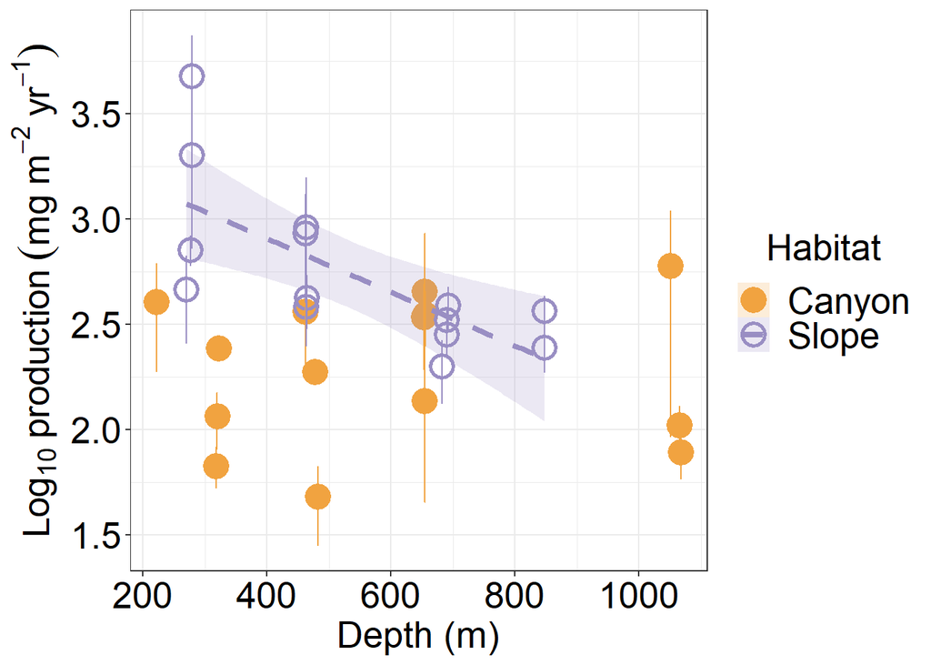

```r
(f4d <- ggplot(data=out,
       aes(x=Depth, y=log10(productionW),
           ymin=log10(productionW-productionW.se), ymax=log10(productionW+productionW.se),
           shape=Habitat, colour=Habitat, fill=Habitat, linetype=Habitat))+
  geom_point(size=5, stroke=1.5, position="jitter")+
  stat_smooth(data=subset(out, Habitat=="Slope"), method="lm", formula=y~x, alpha=0.2, size=1.5)+
  geom_errorbar(linetype=1, position="jitter")+
  scale_colour_manual(values=c("#f1a340", "#998ec3"))+
  scale_fill_manual(values=c("#f1a340", "#998ec3"))+
  scale_linetype_manual(values=c(1,2))+
  scale_shape_manual(values=c(19,1))+
  labs(x="Depth (m)", y=expression(Log[10]~production~(mg~m^-2~yr^-1)))+
  theme_bw() %+replace% large #%+replace% dark
)
```

```r
#save(f4d, file="../rds/f4d.rds")
```

Macrofaunal production declined with depth on the slope.

## 3.3 Main test

```r
f <- gls(log10(productionW) ~ Habitat+Depth+Cruise+Habitat:Depth+Habitat:Cruise+Depth:Cruise, data=out, method = "REML")
kable(summary(f)$tTable)
```

|  | Value | Std.Error | t-value | p-value |
| --- | --- | --- | --- | --- |
| (Intercept) | 2.2771725 | 0.3844165 | 5.9237119 | 0.0000279 |
| HabitatSlope | 0.8330086 | 0.3510328 | 2.3730222 | 0.0314374 |
| Depth | 0.0006550 | 0.0007637 | 0.8576333 | 0.4045903 |
| CruiseOR1_1102 | 0.1869818 | 0.5074889 | 0.3684451 | 0.7176894 |
| CruiseOR1_1114 | -0.3798764 | 0.4847180 | -0.7837059 | 0.4454120 |
| CruiseOR1_1126 | -0.4128473 | 0.5100357 | -0.8094480 | 0.4309111 |
| HabitatSlope:Depth | -0.0016754 | 0.0005291 | -3.1664325 | 0.0063880 |
| HabitatSlope:CruiseOR1_1102 | 0.7094393 | 0.3541948 | 2.0029635 | 0.0635950 |
| HabitatSlope:CruiseOR1_1114 | 0.6593620 | 0.3411158 | 1.9329564 | 0.0723464 |
| HabitatSlope:CruiseOR1_1126 | 0.6250527 | 0.3576085 | 1.7478686 | 0.1009191 |
| Depth:CruiseOR1_1102 | -0.0011466 | 0.0008848 | -1.2959479 | 0.2145803 |
| Depth:CruiseOR1_1114 | 0.0000057 | 0.0008456 | 0.0066873 | 0.9947525 |
| Depth:CruiseOR1_1126 | -0.0002738 | 0.0008486 | -0.3226632 | 0.7514041 |

```r
kable(anova(f))
```

|  | numDF | F-value | p-value |
| --- | --- | --- | --- |
| (Intercept) | 1 | 1864.2788942 | 0.0000000 |
| Habitat | 1 | 15.7093018 | 0.0012487 |
| Depth | 1 | 3.1735868 | 0.0950909 |
| Cruise | 3 | 0.6122561 | 0.6174681 |
| Habitat:Depth | 1 | 6.8240801 | 0.0196129 |
| Habitat:Cruise | 3 | 1.9201891 | 0.1696982 |
| Depth:Cruise | 3 | 1.1299249 | 0.3685470 |

Significant habitat effect, but there are also significant interactions between habitat and depth.

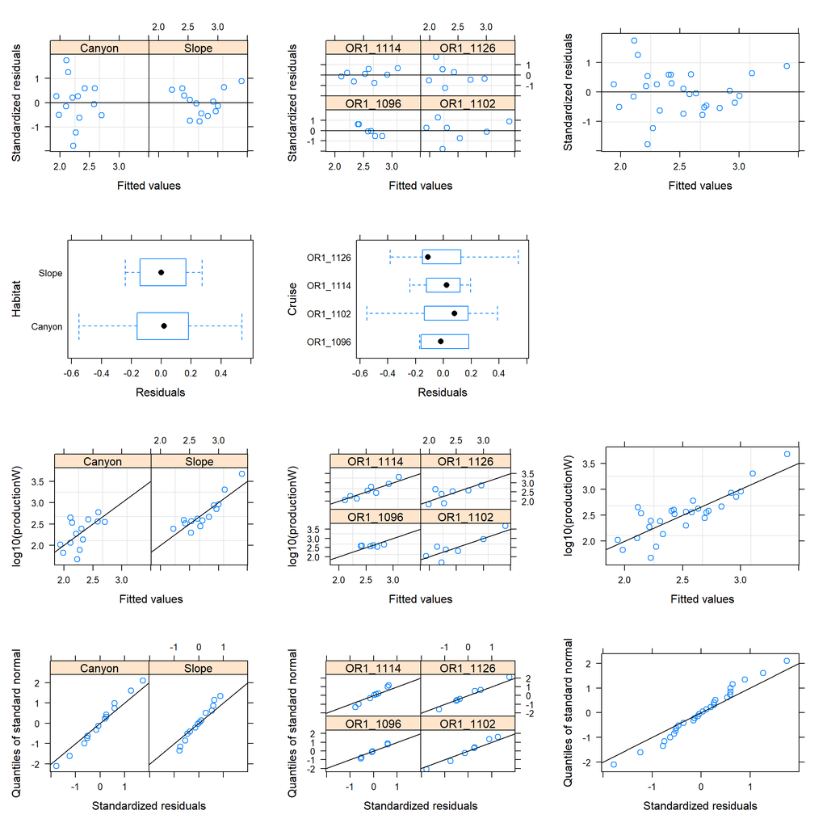

```r
# Dianotics plot
dianostic_plot(f, y = "log10(productionW)")
```

## 3.4 Pairwise tests

```r
# In canyon
f <- gls(log10(productionW) ~ Depth+Cruise+Depth:Cruise, data=subset(out, Habitat == "Canyon"), method = "REML")
kable(summary(f)$tTable)
```

|  | Value | Std.Error | t-value | p-value |
| --- | --- | --- | --- | --- |
| (Intercept) | 2.6315077 | 0.6102284 | 4.3123322 | 0.0050246 |
| Depth | -0.0001389 | 0.0012708 | -0.1093087 | 0.9165218 |
| CruiseOR1_1102 | -0.3755574 | 0.7797180 | -0.4816580 | 0.6471129 |
| CruiseOR1_1114 | -0.8985011 | 0.7814954 | -1.1497203 | 0.2940146 |
| CruiseOR1_1126 | -0.5155311 | 0.8200352 | -0.6286695 | 0.5527302 |
| Depth:CruiseOR1_1102 | -0.0000227 | 0.0014531 | -0.0155909 | 0.9880663 |
| Depth:CruiseOR1_1114 | 0.0010620 | 0.0014582 | 0.7283031 | 0.4938599 |
| Depth:CruiseOR1_1126 | 0.0001501 | 0.0014676 | 0.1022722 | 0.9218730 |

```r
kable(anova(f))
```

|  | numDF | F-value | p-value |
| --- | --- | --- | --- |
| (Intercept) | 1 | 479.3994110 | 0.0000006 |
| Depth | 1 | 0.0060608 | 0.9404779 |
| Cruise | 3 | 0.9613157 | 0.4694843 |
| Depth:Cruise | 3 | 0.4734677 | 0.7120101 |

```r
# On slope
f <- gls(log10(productionW) ~ Depth+Cruise+Depth:Cruise, data=subset(out, Habitat == "Slope"), method = "REML")
kable(summary(f)$tTable)
```

|  | Value | Std.Error | t-value | p-value |
| --- | --- | --- | --- | --- |
| (Intercept) | 2.7118179 | 0.1957972 | 13.8501394 | 0.0000088 |
| Depth | -0.0001830 | 0.0003870 | -0.4728662 | 0.6530199 |
| CruiseOR1_1102 | 1.8830710 | 0.2823527 | 6.6692146 | 0.0005500 |
| CruiseOR1_1114 | 0.9141958 | 0.2544432 | 3.5929272 | 0.0114635 |
| CruiseOR1_1126 | 0.2962262 | 0.2541751 | 1.1654417 | 0.2880715 |
| Depth:CruiseOR1_1102 | -0.0032233 | 0.0005600 | -5.7555716 | 0.0011984 |
| Depth:CruiseOR1_1114 | -0.0012467 | 0.0004699 | -2.6530162 | 0.0378757 |
| Depth:CruiseOR1_1126 | -0.0005593 | 0.0004695 | -1.1913194 | 0.2785122 |

```r
kable(anova(f))
```

|  | numDF | F-value | p-value |
| --- | --- | --- | --- |
| (Intercept) | 1 | 7881.538594 | 0.0000000 |
| Depth | 1 | 70.267240 | 0.0001569 |
| Cruise | 3 | 7.220581 | 0.0204209 |
| Depth:Cruise | 3 | 13.342599 | 0.0046021 |

```r
# GC1 and GS1
f <- gls(log10(productionW) ~ Habitat, data=subset(out, Station=="GC1"|Station=="GS1"), method = "REML")
kable(summary(f)$tTable)
```

|  | Value | Std.Error | t-value | p-value |
| --- | --- | --- | --- | --- |
| (Intercept) | 2.2194239 | 0.2016598 | 11.005784 | 0.0000335 |
| HabitatSlope | 0.9045004 | 0.2851900 | 3.171571 | 0.0192804 |

```r
kable(anova(f))
```

|  | numDF | F-value | p-value |
| --- | --- | --- | --- |
| (Intercept) | 1 | 351.04146 | 0.0000015 |
| Habitat | 1 | 10.05886 | 0.0192804 |

```r
# GC2 and GS2
f <- gls(log10(productionW) ~ Habitat, data=subset(out, Station=="GC2"|Station=="GS2"), method = "REML")
kable(summary(f)$tTable)
```

|  | Value | Std.Error | t-value | p-value |
| --- | --- | --- | --- | --- |
| (Intercept) | 2.1699452 | 0.1867371 | 11.620320 | 0.0000829 |
| HabitatSlope | 0.6040348 | 0.2470300 | 2.445188 | 0.0582804 |

```r
kable(anova(f))
```

|  | numDF | F-value | p-value |
| --- | --- | --- | --- |
| (Intercept) | 1 | 423.280919 | 0.0000050 |
| Habitat | 1 | 5.978945 | 0.0582804 |

```r
# GC3 and GS3
f <- gls(log10(productionW) ~ Habitat, data=subset(out, Station=="GC3"|Station=="GS3"), method = "REML")
kable(summary(f)$tTable)
```

|  | Value | Std.Error | t-value | p-value |
| --- | --- | --- | --- | --- |
| (Intercept) | 2.4663005 | 0.0916415 | 26.9124927 | 0.0000002 |
| HabitatSlope | -0.0034434 | 0.1296006 | -0.0265695 | 0.9796647 |

```r
kable(anova(f))
```

|  | numDF | F-value | p-value |
| --- | --- | --- | --- |
| (Intercept) | 1 | 1446.5427579 | 0.0000000 |
| Habitat | 1 | 0.0007059 | 0.9796647 |

```r
# GC4 and GS4
f <- gls(log10(productionW) ~ Habitat, data=subset(out, Station=="GC4"|Station=="GS4"), method = "REML")
kable(summary(f)$tTable)
```

|  | Value | Std.Error | t-value | p-value |
| --- | --- | --- | --- | --- |
| (Intercept) | 2.2285848 | 0.2287364 | 9.7430266 | 0.0022970 |
| HabitatSlope | 0.2472874 | 0.3616640 | 0.6837489 | 0.5432117 |

```r
kable(anova(f))
```

|  | numDF | F-value | p-value |
| --- | --- | --- | --- |
| (Intercept) | 1 | 172.5668942 | 0.0009529 |
| Habitat | 1 | 0.4675126 | 0.5432117 |

Significant depth effect on slope

# 4 Annual production carbon per square meter

## 4.1 Linear regression with depth

```r
splitBy(~Habitat, out) %>% lapply(FUN=function(x)lm(log10(productionC)~Depth, data=x) %>% summary)
```

```
## $Canyon
##
## Call:
## lm(formula = log10(productionC) ~ Depth, data = x)
##
## Residuals:
##      Min       1Q   Median       3Q      Max
## -0.56320 -0.27163  0.06424  0.20674  0.62846
##
## Coefficients:
##              Estimate Std. Error t value Pr(>|t|)
## (Intercept) 1.1358686  0.2261152   5.023 0.000297 ***
## Depth       0.0002423  0.0003419   0.709 0.492024
## ---
## Signif. codes:  0 '***' 0.001 '**' 0.01 '*' 0.05 '.' 0.1 ' ' 1
##
## Residual standard error: 0.3546 on 12 degrees of freedom
## Multiple R-squared:  0.04018,    Adjusted R-squared:  -0.03981
## F-statistic: 0.5023 on 1 and 12 DF,  p-value: 0.492
##
##
## $Slope
##
## Call:
## lm(formula = log10(productionC) ~ Depth, data = x)
##
## Residuals:
##      Min       1Q   Median       3Q      Max
## -0.34037 -0.18524 -0.00823  0.11933  0.56510
##
## Coefficients:
##               Estimate Std. Error t value Pr(>|t|)
## (Intercept)  2.3552727  0.1838027  12.814 2.32e-08 ***
## Depth       -0.0012716  0.0003243  -3.922  0.00203 **
## ---
## Signif. codes:  0 '***' 0.001 '**' 0.01 '*' 0.05 '.' 0.1 ' ' 1
##
## Residual standard error: 0.2466 on 12 degrees of freedom
## Multiple R-squared:  0.5617, Adjusted R-squared:  0.5252
## F-statistic: 15.38 on 1 and 12 DF,  p-value: 0.002029
```

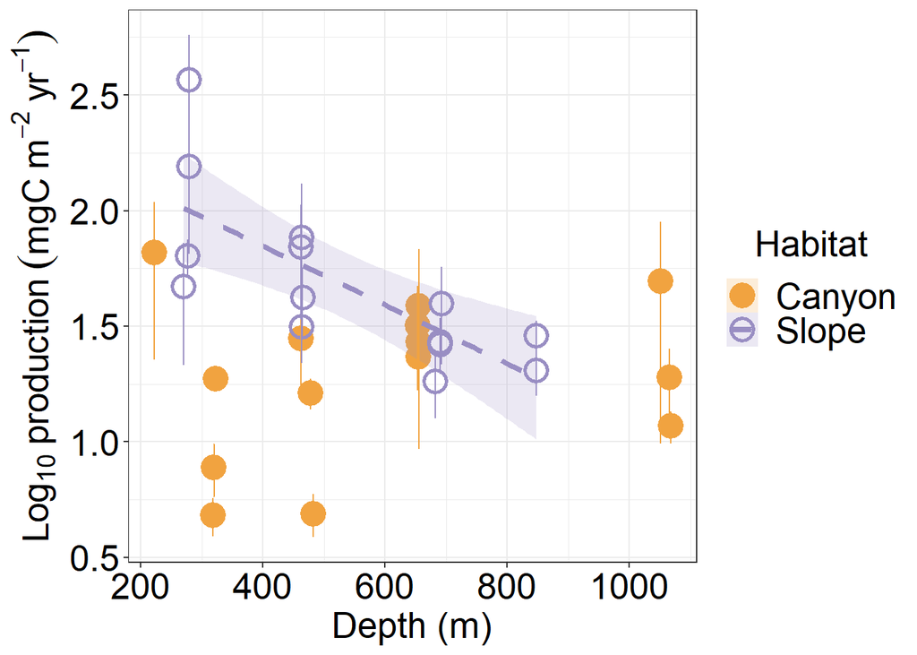

```r
ggplot(data=out,
       aes(x=Depth, y=log10(productionC),
           ymin=log10(productionC-productionC.se), ymax=log10(productionC+productionC.se),
           shape=Habitat, colour=Habitat, fill=Habitat, linetype=Habitat))+
  geom_point(size=5, stroke=1.5, position="jitter")+
  stat_smooth(data=subset(out, Habitat=="Slope"), method="lm", formula=y~x, alpha=0.2, size=1.5)+
  geom_errorbar(linetype=1, position="jitter")+
  scale_colour_manual(values=c("#f1a340", "#998ec3"))+
  scale_fill_manual(values=c("#f1a340", "#998ec3"))+
  scale_linetype_manual(values=c(1,2))+
  scale_shape_manual(values=c(19,1))+
  labs(x="Depth (m)", y=expression(Log[10]~production~(mgC~m^-2~yr^-1)))+
  theme_bw() %+replace% large #%+replace% dark
```

# 5 Annual production J per square meter

## 5.1 Linear regression with depth

```r
splitBy(~Habitat, out) %>% lapply(FUN=function(x)lm(log10(productionJ)~Depth, data=x) %>% summary)
```

```
## $Canyon
##
## Call:
## lm(formula = log10(productionJ) ~ Depth, data = x)
##
## Residuals:
##     Min      1Q  Median      3Q     Max
## -0.5752 -0.2720  0.0483  0.2086  0.6228
##
## Coefficients:
##              Estimate Std. Error t value Pr(>|t|)
## (Intercept) 2.8063323  0.2290932  12.250 3.84e-08 ***
## Depth       0.0001986  0.0003464   0.573    0.577
## ---
## Signif. codes:  0 '***' 0.001 '**' 0.01 '*' 0.05 '.' 0.1 ' ' 1
##
## Residual standard error: 0.3593 on 12 degrees of freedom
## Multiple R-squared:  0.02665,    Adjusted R-squared:  -0.05446
## F-statistic: 0.3285 on 1 and 12 DF,  p-value: 0.5771
##
##
## $Slope
##
## Call:
## lm(formula = log10(productionJ) ~ Depth, data = x)
##
## Residuals:
##      Min       1Q   Median       3Q      Max
## -0.32589 -0.18644 -0.00822  0.12005  0.56669
##
## Coefficients:
##               Estimate Std. Error t value Pr(>|t|)
## (Intercept)  4.0173037  0.1831288  21.937 4.73e-11 ***
## Depth       -0.0012876  0.0003231  -3.986  0.00181 **
## ---
## Signif. codes:  0 '***' 0.001 '**' 0.01 '*' 0.05 '.' 0.1 ' ' 1
##
## Residual standard error: 0.2457 on 12 degrees of freedom
## Multiple R-squared:  0.5697, Adjusted R-squared:  0.5338
## F-statistic: 15.89 on 1 and 12 DF,  p-value: 0.001808
```

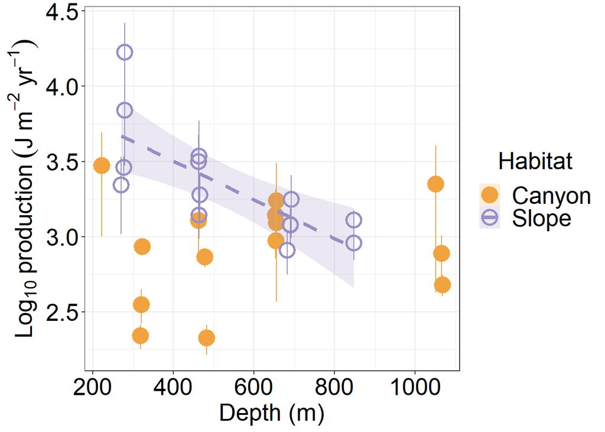

```r
ggplot(data=out,
       aes(x=Depth, y=log10(productionJ),
           ymin=log10(productionJ-productionJ.se), ymax=log10(productionJ+productionJ.se),
           shape=Habitat, colour=Habitat, fill=Habitat, linetype=Habitat))+
  geom_point(size=5, stroke=1.5, position="jitter")+
  stat_smooth(data=subset(out, Habitat=="Slope"), method="lm", formula=y~x, alpha=0.2, size=1.5)+
  geom_errorbar(linetype=1, position="jitter")+
  scale_colour_manual(values=c("#f1a340", "#998ec3"))+
  scale_fill_manual(values=c("#f1a340", "#998ec3"))+
  scale_linetype_manual(values=c(1,2))+
  scale_shape_manual(values=c(19,1))+
  labs(x="Depth (m)", y=expression(Log[10]~production~(J~m^-2~yr^-1)))+
  theme_bw() %+replace% large #%+replace% dark
```